# 计算物理第一次习题课

python常用库：NumPy和Matplotlib

王豪 $\quad \quad \quad \quad$

# python常用库——NumPy

NumPy，全名为"Numerical Python"，是Python中用于科学计算和数据分析的重要库之一。它提供了强大的多维数组对象和用于处理这些数组的函数。

- **高性能计算：** NumPy的底层实现是用C语言编写的，这使得它在处理大型数据集时非常高效。NumPy中的矢量化操作允许您在不使用显式循环的情况下进行数组操作，从而提高了计算速度。
- **广泛的数学函数：** NumPy提供了许多内置的数学函数，包括数学运算、统计和线性代数运算等。这使得它成为进行科学计算的理想工具。
- **数据结构：** NumPy引入了多维数组对象（numpy.ndarray），这些数组能够容纳同一数据类型的元素。这对于处理大规模数据集非常重要，因为它确保了数据的一致性和效率。

## 1.NumPy数组基础

### 创建NumPy数组

```python
import numpy as np

# 创建一个一维数组
arr1 = np.array([1, 2, 3, 4, 5, 6], dtype='float')
arr1
```

```
array([1., 2., 3., 4., 5., 6.])
```

```python
# 创建一个二维数组
arr2 = np.array([[1, 2, 3], [4, 5, 6], [7, 8, 9]])
arr2
```

```
array([[1, 2, 3],
       [4, 5, 6],
       [7, 8, 9]])
```

```python
# 创建等差数组
arr3 = np.arange(0,6,1)    #含首不含尾
arr4 = np.linspace(0,5,6)   #含首含尾
print(arr3)
print(arr4)
```

```
[0 1 2 3 4 5]
[0. 1. 2. 3. 4. 5.]
```

### 数组的属性：形状、数据类型

形状表示数组的维度和每个维度的大小。可以使用'shape'属性来访问数组的形状，也可以使用'reshape'来改变数组形状

```python
print(arr1.shape)
print(arr2.shape)
```

```
(6,)
(3, 3)
```

```python
arr1.reshape(2,3)
```

```
array([[1., 2., 3.],
       [4., 5., 6.]])
```

数据类型表示数组中元素的类型。NumPy支持多种数据类型，如整数、浮点数、复数等。可以使用dtype属性来查看数组的数据类型。

```python
print(arr1.dtype)
print(arr2.dtype)
```

```
float64
int32
```

### 访问数组元素：索引和切片

索引从0开始，通过指定索引来访问特定元素。 $\quad arr1=\left( \begin{array} & 1 & 2 & 3 & 4 & 5 \end{array} \right) \quad arr2=\left( \begin{array} &1 & 2 & 3 \\ 4 & 5 &6 \\ 7 & 8 & 9\\ \end{array} \right)$

```python
print(arr1[0])   # 第一个元素
print(arr2[1, 2])  # 第二行，第三列
```

```
1.0
6
```

切片允许选择数组的一部分。例如，要选择一个范围内的元素，可以使用切片：

```python
print(arr1[1 :4])  # 选择索引1到3的元素，即第2到第4元素
print(arr2[0:2, 1:3])  # 第1到2行，第2到3列
```

```
[2. 3. 4.]
[[2 3]
 [5 6]]
```

### 数组操作：基本运算

对于数组的基本运算，都是逐元素进行

```python
arr1 = np.array([1, 2, 3])
arr2 = np.array([4, 5, 6])
```

```python
arr1 + arr2
```

```
array([5, 7, 9])
```

```python
arr1 * arr2
```

```
array([ 4, 10, 18])
```

```python
arr1 ** arr2
```

```
array([  1,  32, 729])
```

```python
arr1 ** 2
```

```
array([1, 4, 9])
```

```python
np.sin(arr1 * np.pi / 2 )
```

```
array([ 1.0000000e+00,  1.2246468e-16, -1.0000000e+00])
```

## 2. 矩阵运算

**创建矩阵** $\quad A=\left( \begin{smallmatrix} 1 & 2 \\ 3 & 4 \\ \end{smallmatrix} \right) \quad B=\left( \begin{smallmatrix} 4 & 3 \\ 2 & 1 \\ \end{smallmatrix} \right) $

```python
A = np.mat([[1, 2], [3, 4]])
B = np.mat('4, 3; 2, 1')
B
```

```
matrix([[4, 3],
        [2, 1]])
```

```python
A + B   #矩阵加法
```

```
matrix([[5, 5],
        [5, 5]])
```

```python
A * B   #矩阵乘法
```

```
matrix([[ 8,  5],
        [20, 13]])
```

```python
np.multiply(A, B)   #对应元素相乘
```

```
matrix([[4, 6],
        [6, 4]])
```

```python
A.T   #矩阵转置
```

```
matrix([[1, 3],
        [2, 4]])
```

```python
np.trace(A)  #矩阵求迹
```

```
5
```

```python
C = np.mat([[1+1j, 2+2j],[3+3j, 4+4j]])
C.H        #转置共轭
```

```
matrix([[1.-1.j, 3.-3.j],
        [2.-2.j, 4.-4.j]])
```

```python
np.linalg.det(A)   #矩阵行列式
```

```
-2.0000000000000004
```

```python
A.I   #矩阵求逆
```

```
matrix([[-2. ,  1. ],
        [ 1.5, -0.5]])
```

**注意：矩阵求逆和行列式在作业中不可直接使用，如要使用需要自己编写算法**

**使用array创建矩阵（即二维数组）**

```python
A = np.array([[1, 2], [3, 4]])
B = np.eye(2)  #单位矩阵
```

```python
A * B   #对应元素相乘
```

```
array([[1., 0.],
       [0., 4.]])
```

```python
np.dot(A, B)   #矩阵乘法
```

```
array([[1., 2.],
       [3., 4.]])
```

```python
A.T   #矩阵转置
```

```
array([[1, 3],
       [2, 4]])
```

```python
C = np.array([[1+1j, 2+2j],[3+3j, 4+4j]])
np.conjugate(C.T)    #转置共轭
```

```
array([[1.-1.j, 3.-3.j],
       [2.-2.j, 4.-4.j]])
```

```python
np.linalg.inv(A)   #矩阵求逆
```

```
array([[-2. ,  1. ],
       [ 1.5, -0.5]])
```

## 3. 常用数学函数

- $\pi$： np.pi
- 自然常数e：np.e
- 正弦：np.sin(x)
- 反正弦：np.arcsin(x)
- 自然指数：np.exp(x)
- 自然对数：np.log(x)
- 对数：np.log(x, base)
- 绝对值：np.abs(x)
- 符号函数：np.sign(x)
- 阶跃函数：np.heaviside(x, definition_at_0)
- 四舍五入：np.round(x)
- 向下取整：np.floor(x)
- 向上取整：np.ceil(x)
- 取余数：np.mod(x, y)
- 最大值：np.max(x)
- 最小值：np.min(x)
- 求和：np.sum(x)
- 平均值：np.mean(x)
- 中位数：np.median(x)
- 标准差：np.std(x)

# python常用库——Matplotlib

Matplotlib 是 Python 生态系统的一个重要组成部分，是用于可视化的绘图库，可以生成出版质量级别的精美图形，Matplotlib 使绘图变得非常简单，在易用性和性能间取得了优异的平衡。

图例、标题、坐标轴中使用中文会导致乱码，可在导入库时加入以下代码以使中文可用

```python
import matplotlib.pyplot as plt

plt.rcParams['font.sans-serif'] = ['SimHei']  #黑体
plt.rcParams['axes.unicode_minus'] = False
```

## 1.基本图形绘制

绘制单张图时可以直接使用对应的绘图函数

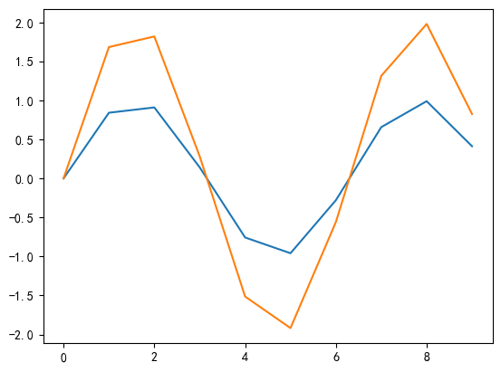

```python
x = np.arange(0,10,1)
y = np.sin(x)
plt.plot(x,y)
plt.plot(x,2*y)
plt.show()
```

绘制多个子图

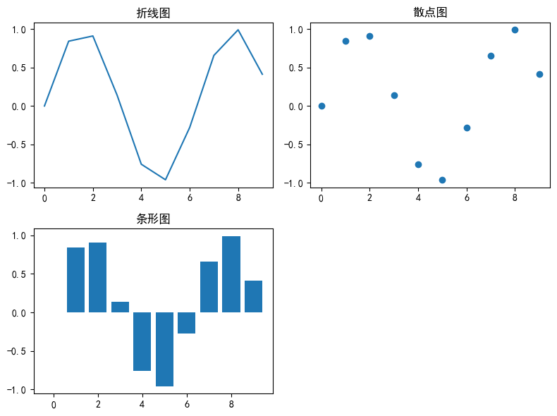

```python
# 创建一个 2x2 的子图网格
fig, axes = plt.subplots(nrows=2, ncols=2, figsize=(8, 6))

#在各个子图中绘图
axes[0, 0].plot(x, y)
axes[0, 0].set_title('折线图')

axes[0, 1].scatter(x, y)
axes[0, 1].set_title('散点图')

axes[1, 0].bar(x, y)
axes[1, 0].set_title('条形图')

axes[1, 1].axis('off')  #第四个子图为空

plt.tight_layout()  #自动调整子图或子图之间的距离和边界
plt.show()
```

## 2.自定义图形属性

通常需要对图形添加标题、标签、图例等内容，也可以对图形的线性、颜色、尺寸、分辨率等内容进行定义

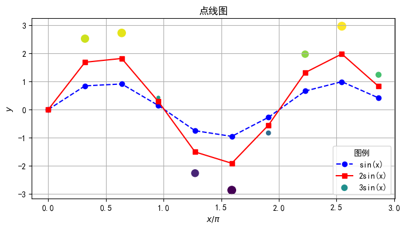

```python
# 创建图形和坐标轴
fig, ax = plt.subplots()

# 绘制数据并进行自定义
ax.plot(x/np.pi, y, color='blue', linestyle='--', marker='o', label='sin(x)')
ax.plot(x/np.pi, 2*y, 'r-s', label='2sin(x)')
ax.scatter(x/np.pi, 3*y, marker='o', c=y, s=100*np.abs(y), cmap='viridis', label='3sin(x)')
ax.set_title('点线图')
ax.set_xlabel('$x/\pi$')
ax.set_ylabel('$y$')

# 自定义图形尺寸和分辨率
fig.set_size_inches(8, 4)
fig.set_dpi(100)

# 添加和自定义图例
ax.legend(loc='lower right', title='图例')
ax.grid(True)

# 显示图形
plt.show()
```

## 3.其他二维图

- **热力图 (Heatmap):**  
  热力图是一种可视化工具，用于显示矩形数据表中的数据，其中颜色表示数据值的大小。
- **等高线图 (Contour Plot):**  
  等高线图显示二维数据的等高线，其中等高线表示相同数值的点。

**热力图**

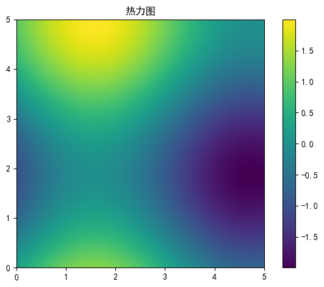

```python
# 创建数据点
x = np.linspace(0, 5, 1000)
y = np.linspace(0, 5, 1000)
x_grid, y_grid = np.meshgrid(x, y)  # 创建网格
z = np.sin(x_grid) + np.cos(y_grid)  # 模拟数据点

# 创建图形和坐标轴对象
fig, ax = plt.subplots()

# 绘制热力图
heatmap = ax.imshow(z, cmap='viridis', extent=[0, 5, 0, 5])
ax.set_title('热力图')

# 添加颜色条
cbar = fig.colorbar(heatmap, ax=ax)

# 显示图形
plt.tight_layout()
plt.show()
```

**等高线图**

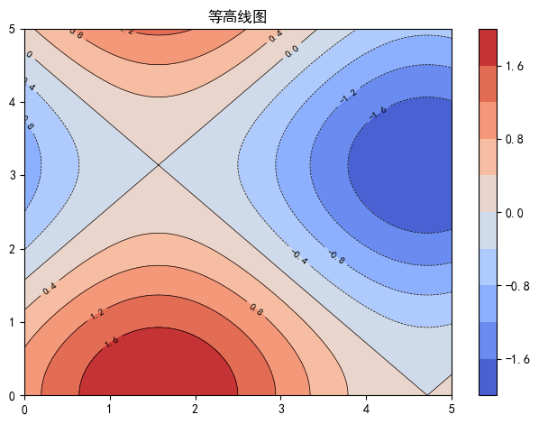

```python
# 创建图形和坐标轴对象
fig, ax = plt.subplots()

# 绘制等高线图
contour = ax.contour(x, y, z, levels=10, colors='black', linewidths=0.5)

# 添加等高线标签
ax.clabel(contour, inline=1, fontsize=8, colors='black')

# 添加颜色填充
cfill = ax.contourf(x, y, z, levels=10, cmap='coolwarm')

# 添加颜色条
cbar = fig.colorbar(cfill, ax=ax)
ax.set_title('等高线图')

# 显示图形
plt.tight_layout()
plt.show()
```

## 4.三维图形

- 3D绘图用于显示三维数据，其中包括x、y和z轴。它允许我们可视化数据点的分布、表面的形状以及数据之间的关系。
- 3D绘图通常包括3D线图、散点图和表面图等类型。
- 在Matplotlib中，我们使用mpl_toolkits.mplot3d库来创建3D图形。您可以创建一个3D图形对象，通常是一个Axes3D对象，用于绘制3D图形。
- 我们可以自定义3D图形的属性，包括颜色、标记、线型、透明度等，以使图形更具吸引力和信息量。

**3D线图**

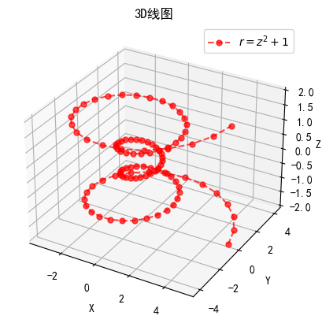

```python
from mpl_toolkits.mplot3d import Axes3D

# 创建数据
theta = np.linspace(-4 * np.pi, 4 * np.pi, 100)
z = np.linspace(-2, 2, 100)
r = z**2 + 1

# 创建图形和3D坐标轴对象
fig = plt.figure()
ax = fig.add_subplot(111, projection='3d')

# 绘制3D线图
ax.plot(r * np.cos(theta), r * np.sin(theta), z, label='$r=z^2+1$', color='r', linestyle='dashed', marker='o', markersize=5, alpha=0.7)
ax.set_xlabel('X')
ax.set_ylabel('Y')
ax.set_zlabel('Z', labelpad=-1)
ax.set_title('3D线图')
ax.legend()
plt.show()
```

**3D散点图**

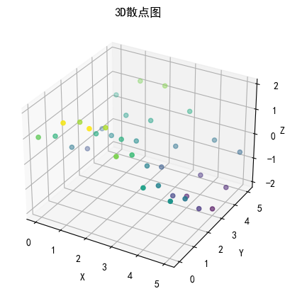

```python
# 创建数据点
x = np.linspace(0, 5, 6)
y = np.linspace(0, 5, 6)
x_grid, y_grid = np.meshgrid(x, y)  # 创建网格
z = np.sin(x_grid) + np.cos(y_grid)  # 模拟数据点

# 创建图形和3D坐标轴对象
fig = plt.figure()
ax = fig.add_subplot(111, projection='3d')

# 绘制3D散点图
ax.scatter(x_grid, y_grid, z, c=z, marker='o', cmap='viridis')
ax.set_xlabel('X')
ax.set_ylabel('Y')
ax.set_zlabel('Z', labelpad=-4)
ax.set_title('3D散点图')
plt.show()
```

**3D表面图**

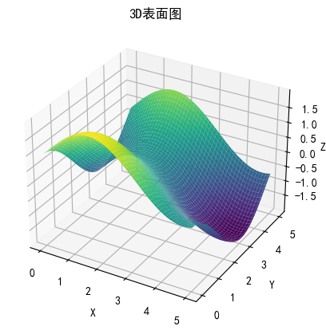

```python
# 创建数据点
x = np.linspace(0, 5, 100)
y = np.linspace(0, 5, 100)
x_grid, y_grid = np.meshgrid(x, y)  # 创建网格
z = np.sin(x_grid) + np.cos(y_grid)  # 模拟数据点

# 创建图形和3D坐标轴对象
fig = plt.figure()
ax = fig.add_subplot(111, projection='3d')

# 绘制3D表面图
ax.plot_surface(x_grid, y_grid, z, cmap='viridis', linewidth=10, antialiased=True, alpha=1)
ax.set_xlabel('X')
ax.set_ylabel('Y')
ax.set_zlabel('Z', labelpad=-1)
ax.set_title('3D表面图')
plt.show()
```

## 5.ColorMap

在前面的绘图中，有些场景使用了cmap参数，用于定义数值与颜色的映射规则，常用的cmap如下：

[figure not shown]

# 实际应用

课程和作业内容是为了帮助学生更好地理解各种算法，而在实际的科研中，通常可以使用现成的库来实现相应的功能

**这部分内容在作业中不可直接使用**

## 线性方程组的求解

np.linalg.solve(A, b) 函数用于求解形如 Ax = b 的线性方程组，以下是一个示例：

```python
# 系数矩阵 A
A = np.array([[2, 3], [1, -2]])

# 右侧常数向量 b
b = np.array([5, 3])

# 使用 np.linalg.solve() 求解线性方程组
x = np.linalg.solve(A, b)
print("Solution x:", x)
```

```
Solution x: [ 2.71428571 -0.14285714]
```

## 特征值和特征向量

np.linalg.eig(matrix) 函数用于计算矩阵的特征值和特征向量。特征值是标量，所有特征值组成一个一维数组；特征向量是列向量，所有特征向量组成一个二维数组。以下是一个示例：

```python
eigenvalues, eigenvectors = np.linalg.eig(A)
print("Eigenvalues:\n", eigenvalues)
print("Eigenvectors:\n", eigenvectors)
```

```
Eigenvalues:
 [ 2.64575131 -2.64575131]
Eigenvectors:
 [[ 0.97760877 -0.54247681]
 [ 0.21043072  0.84007078]]
```

验证

```python
print(np.dot(A, eigenvectors[:,0])-eigenvalues[0]*eigenvectors[:,0])
print(np.dot(A, eigenvectors[:,1])-eigenvalues[1]*eigenvectors[:,1])
```

```
[8.8817842e-16 0.0000000e+00]
[-4.4408921e-16  0.0000000e+00]
```

## 一维插值

可以使用SciPy的scipy.interpolate.interp1d函数来实现一维插值，只需更改kind参数以选择所需的插值方法。这个函数支持线性插值、多项式插值、三次样条插值和更多方法。

```python
from scipy.interpolate import interp1d
import numpy as np

# 创建一维数据点
x = np.array([0, 1, 2, 3, 4, 5, 6, 7, 8, 9, 10])
y = np.array([0, 2, 1, 3, 4, 2, 6, 3, 1, 0, 4])

# 使用 interp1d 进行不同插值方法
linear_interp = interp1d(x, y, kind='linear')
polynomial_interp = interp1d(x, y, kind='quadratic')
cubic_spline_interp = interp1d(x, y, kind='cubic')

# 生成插值结果
x_new = np.linspace(0, 10, 500)  # 更多数据点
y_linear = linear_interp(x_new)
y_polynomial = polynomial_interp(x_new)
y_cubic_spline = cubic_spline_interp(x_new)
```

绘制插值结果

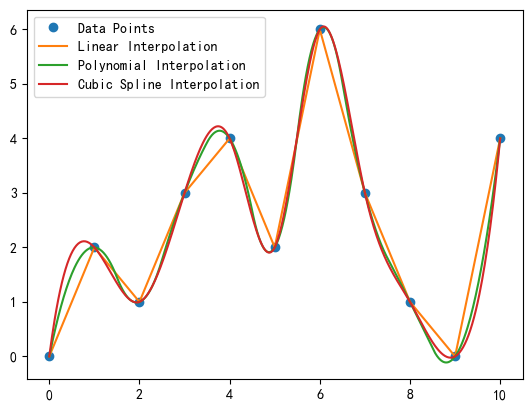

```python
import matplotlib.pyplot as plt

plt.plot(x, y, 'o', label='Data Points')
plt.plot(x_new, y_linear, label='Linear Interpolation')
plt.plot(x_new, y_polynomial, label='Polynomial Interpolation')
plt.plot(x_new, y_cubic_spline, label='Cubic Spline Interpolation')
plt.legend()
plt.show()
```

## 二维插值

可以使用SciPy的scipy.interpolate.griddata函数来实现二维插值，只需更改method参数以选择所需的插值方法。这里以三次样条插值为例：

```python
import numpy as np
from scipy.interpolate import griddata

# 创建二维数据点
x = np.linspace(0, 5, 6)
y = np.linspace(0, 5, 6)
x_grid, y_grid = np.meshgrid(x, y)   #创建网格
z = np.sin(x_grid) + np.cos(y_grid)  # 模拟数据点

# 定义网格坐标
x_new = np.linspace(0, 5, 100)
y_new = np.linspace(0, 5, 100)
x_grid_new, y_grid_new = np.meshgrid(x_new, y_new)

# 使用 griddata 进行三次样条插值
points = np.column_stack((x_grid.flatten(), y_grid.flatten()))   #将网格转化为一个一个(x,y)坐标
grid_z_cubic = griddata(points, z.flatten(), (x_grid_new, y_grid_new), method='cubic')
```

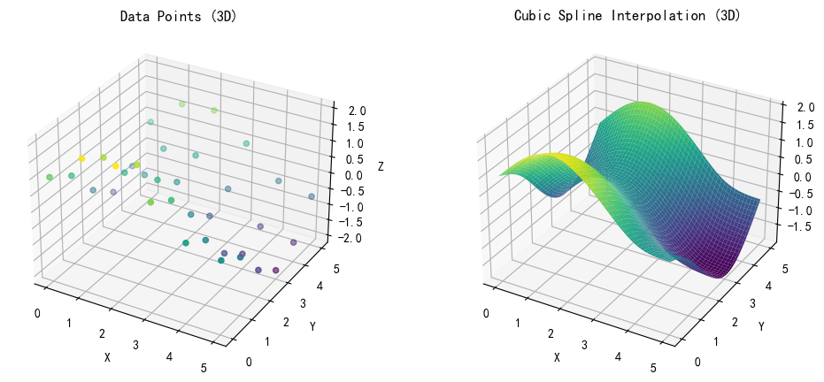

```python
import matplotlib.pyplot as plt
from mpl_toolkits.mplot3d import Axes3D

fig = plt.figure(figsize=(12, 5))
# 绘制原始的数据点
ax1 = fig.add_subplot(121, projection='3d')
ax1.scatter(x_grid, y_grid, z, c=z, marker='o', cmap='viridis')
ax1.set_xlabel('X'); ax1.set_ylabel('Y'); ax1.set_zlabel('Z')
ax1.set_title('Data Points (3D)')
# 绘制插值后的三维图
ax2 = fig.add_subplot(122, projection='3d')
ax2.plot_surface(x_grid_new, y_grid_new, grid_z_cubic, cmap='viridis')
ax2.set_xlabel('X'); ax2.set_ylabel('Y'); ax2.set_zlabel('Z')
ax2.set_title('Cubic Spline Interpolation (3D)')

plt.show()
```

# Jupyter notebook

Jupyter Notebook（此前被称为 IPython notebook）是一个交互式笔记本，支持运行 40 多种编程语言。

Jupyter Notebook是一个开源的Web应用程序，允许用户创建和共享包含代码、方程式、可视化和文本的文档，支持实时代码，数学方程，可视化和 markdown。

使用教程：

https://blog.csdn.net/weixin_44015669/article/details/104974340

markdown基础语法：

https://blog.csdn.net/weixin_44852067/article/details/122220945

## 插件库安装

安装教程和常用插件：

https://blog.csdn.net/qq_40206371/article/details/119655931